# Terroir

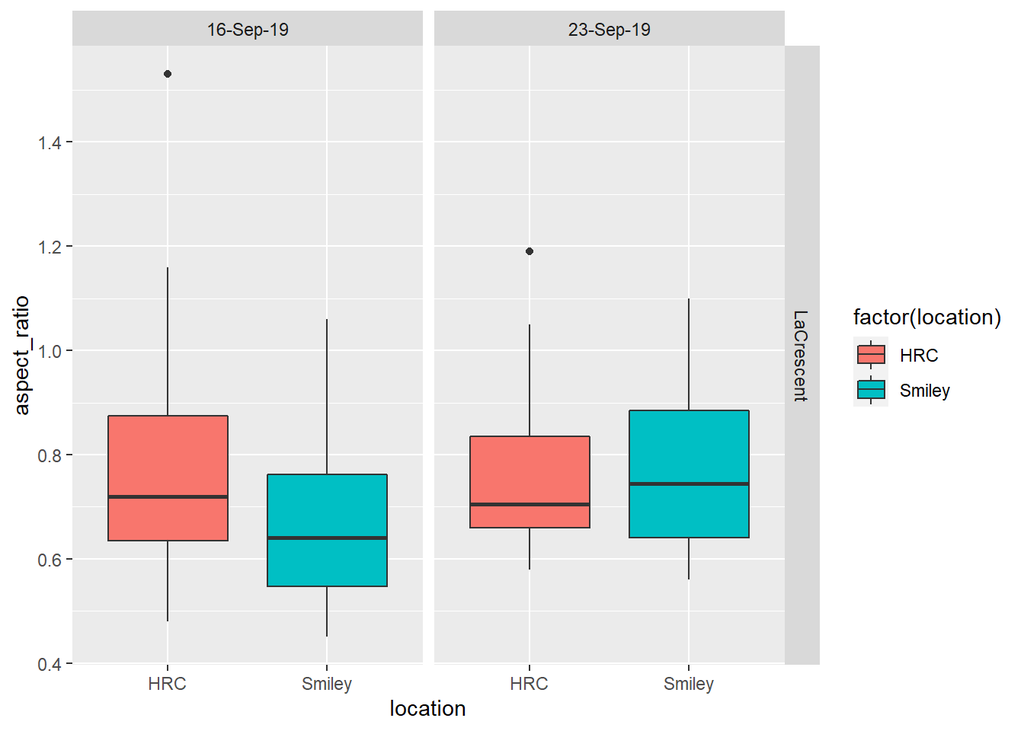

```r
ggplot(data, aes(aspect_ratio, location, fill=factor(location)))+ #use this box plot!
  geom_boxplot()+
  coord_flip()+
  facet_grid(variety~date, scales="free")
```

##Linear model and ANOVA Week a only

```r
asp_rat_a <- lm(aspect_ratio ~ location+cluster+image+location*cluster*image, weeka)
anova(asp_rat_a)
```

```
## Analysis of Variance Table
##
## Response: aspect_ratio
##                        Df  Sum Sq  Mean Sq F value   Pr(>F)
## location                1 0.22791 0.227911  8.4602 0.004824 **
## cluster                 1 0.12451 0.124506  4.6217 0.034929 *
## image                   1 0.05130 0.051302  1.9044 0.171860
## location:cluster        1 0.02406 0.024061  0.8932 0.347784
## location:image          1 0.02088 0.020880  0.7751 0.381577
## cluster:image           1 0.03921 0.039209  1.4555 0.231601
## location:cluster:image  1 0.08155 0.081553  3.0273 0.086148 .
## Residuals              72 1.93963 0.026939
## ---
## Signif. codes:  0 '***' 0.001 '**' 0.01 '*' 0.05 '.' 0.1 ' ' 1
```

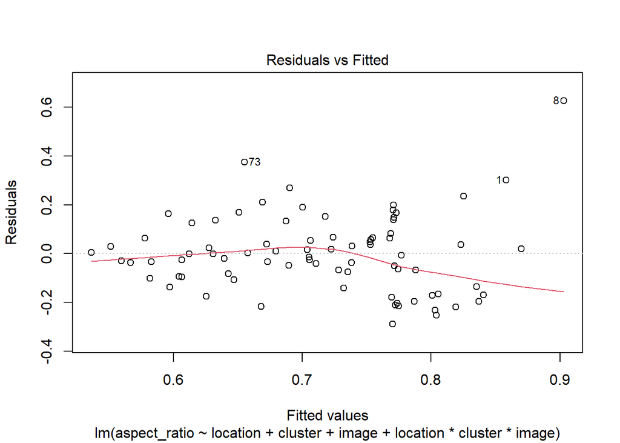

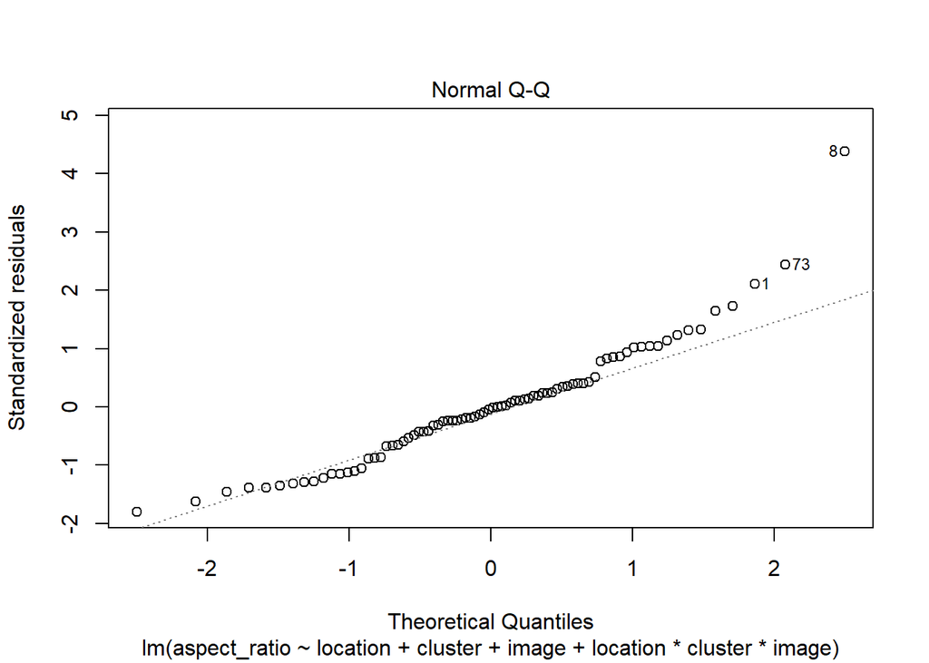

```r
plot(asp_rat_a,which=c(1,2))
```

##Linear model and ANOVA Week b only

```r
asp_rat_b <- lm(aspect_ratio ~ location+cluster+image+cluster*image*location, weekb)
anova(asp_rat_b)
```

```
## Analysis of Variance Table
##
## Response: aspect_ratio
##                        Df  Sum Sq  Mean Sq F value Pr(>F)
## location                1 0.00036 0.000360  0.0140 0.9066
## cluster                 1 0.00552 0.005523  0.2144 0.6465
## image                   1 0.04761 0.047610  1.8483 0.1835
## cluster:image           1 0.00184 0.001844  0.0716 0.7908
## location:cluster        1 0.01589 0.015891  0.6169 0.4380
## location:image          1 0.00625 0.006250  0.2426 0.6257
## location:cluster:image  1 0.03840 0.038405  1.4909 0.2310
## Residuals              32 0.82428 0.025759
```

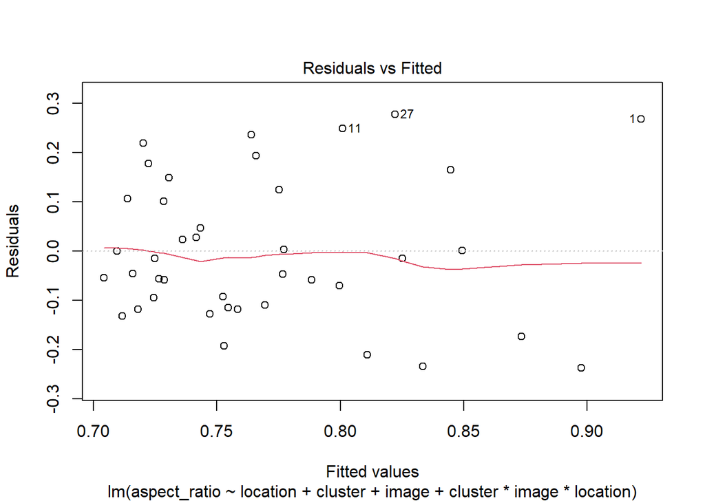

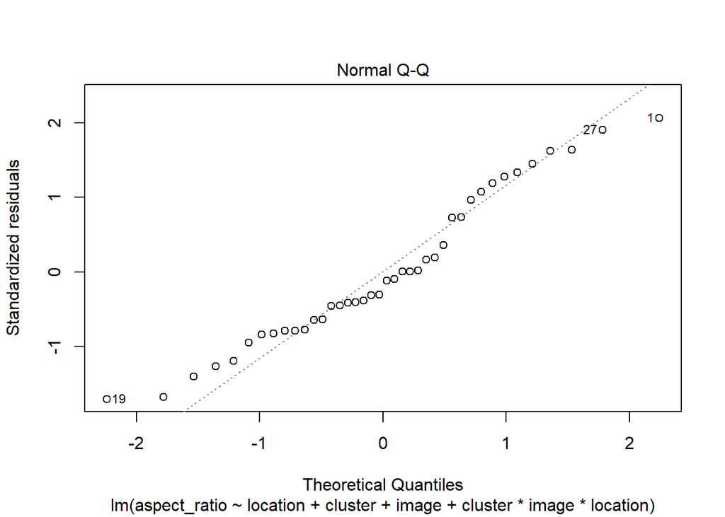

```r
plot(asp_rat_b,which=c(1,2))
```

#cluster roundness ##Linear model and ANOVA

```r
cl_rnd <- lm(cluster_roundness ~ location+cluster+image+date+location*cluster*image*date, data)
anova(cl_rnd)
```

```
## Analysis of Variance Table
##
## Response: cluster_roundness
##                              Df   Sum Sq  Mean Sq F value    Pr(>F)
## location                      1 0.049207 0.049207 17.1864 6.928e-05 ***
## cluster                       1 0.007948 0.007948  2.7758 0.0987098 .
## image                         1 0.004025 0.004025  1.4058 0.2384651
## date                          1 0.015779 0.015779  5.5110 0.0207905 *
## location:cluster              1 0.032876 0.032876 11.4823 0.0009934 ***
## location:image                1 0.004742 0.004742  1.6561 0.2009899
## cluster:image                 1 0.005869 0.005869  2.0500 0.1552077
## location:date                 1 0.036320 0.036320 12.6854 0.0005576 ***
## cluster:date                  1 0.007971 0.007971  2.7840 0.0982182 .
## image:date                    1 0.000145 0.000145  0.0508 0.8221159
## location:cluster:image        1 0.011204 0.011204  3.9130 0.0505586 .
## location:cluster:date         1 0.000362 0.000362  0.1264 0.7228898
## location:image:date           1 0.000076 0.000076  0.0267 0.8705129
## cluster:image:date            1 0.004222 0.004222  1.4746 0.2273642
## location:cluster:image:date   1 0.000263 0.000263  0.0919 0.7624213
## Residuals                   104 0.297769 0.002863
## ---
## Signif. codes:  0 '***' 0.001 '**' 0.01 '*' 0.05 '.' 0.1 ' ' 1
```

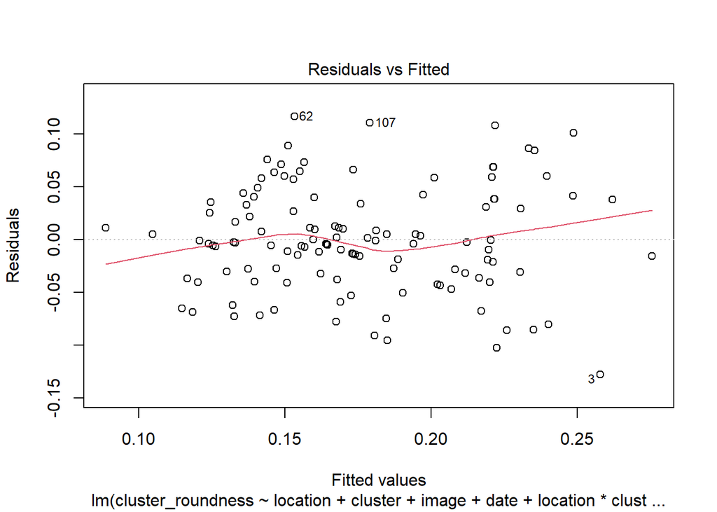

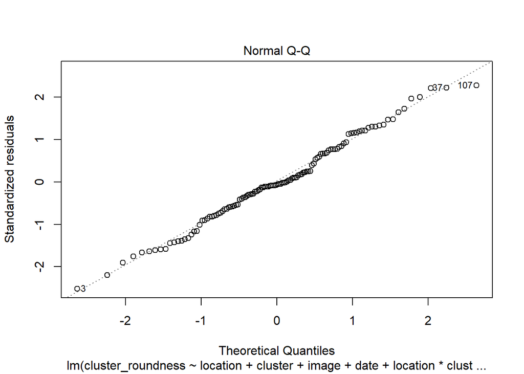

```r
plot(cl_rnd,which=c(1,2))
```

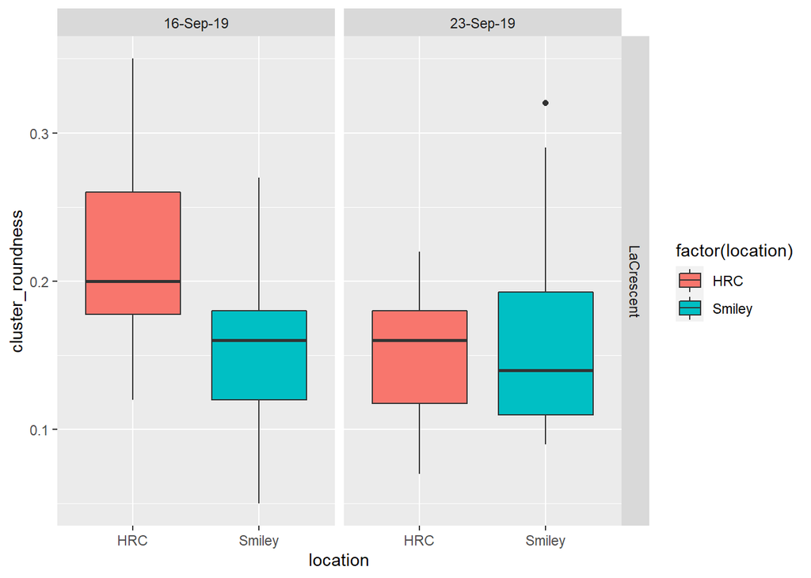

```r
ggplot(data, aes(cluster_roundness, location, fill=factor(location)))+ #use this box plot!
  geom_boxplot()+
  coord_flip()+
  facet_grid(variety~date, scales="free")
```

##Linear model and ANOVA week a

```r
cl_rnd_a <- lm(cluster_roundness ~ location+cluster+image+location*cluster*image, weeka)
anova(cl_rnd_a)
```

```
## Analysis of Variance Table
##
## Response: cluster_roundness
##                        Df   Sum Sq  Mean Sq F value    Pr(>F)
## location                1 0.088445 0.088445 31.0314 4.137e-07 ***
## cluster                 1 0.000049 0.000049  0.0172 0.8959520
## image                   1 0.000025 0.000025  0.0088 0.9256429
## location:cluster        1 0.034186 0.034186 11.9942 0.0009023 ***
## location:image          1 0.000576 0.000576  0.2021 0.6543876
## cluster:image           1 0.002258 0.002258  0.7924 0.3763433
## location:cluster:image  1 0.006028 0.006028  2.1149 0.1502202
## Residuals              72 0.205213 0.002850
## ---
## Signif. codes:  0 '***' 0.001 '**' 0.01 '*' 0.05 '.' 0.1 ' ' 1
```

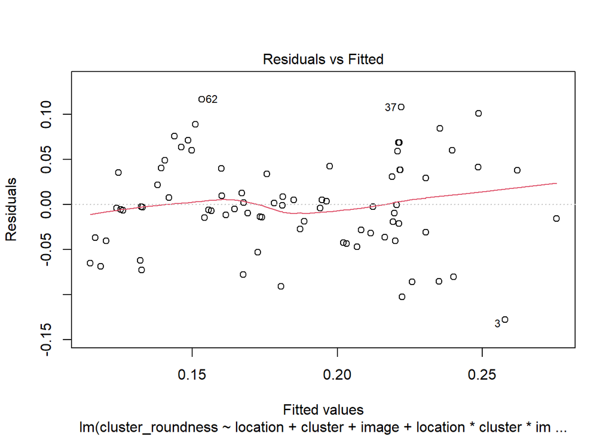

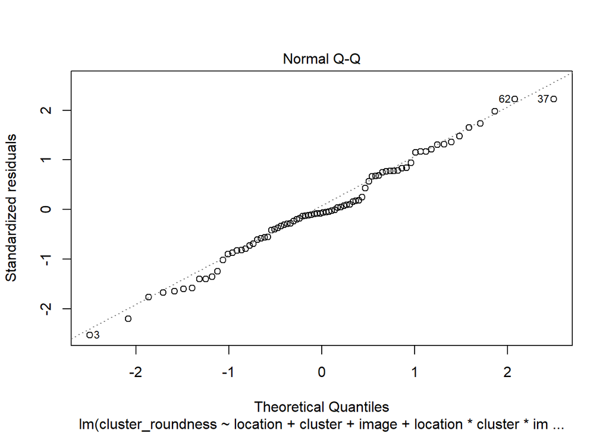

```r
plot(cl_rnd_a,which=c(1,2))
```

##Linear model and ANOVA week b

```r
cl_rnd_b <- lm(cluster_roundness ~ location+cluster+image +location*cluster*image, weekb)
anova(cl_rnd_b)
```

```
## Analysis of Variance Table
##
## Response: cluster_roundness
##                        Df   Sum Sq   Mean Sq F value  Pr(>F)
## location                1 0.001322 0.0013225  0.4572 0.50378
## cluster                 1 0.020881 0.0208807  7.2192 0.01134 *
## image                   1 0.000123 0.0001225  0.0424 0.83825
## location:cluster        1 0.002764 0.0027637  0.9555 0.33565
## location:image          1 0.000002 0.0000025  0.0009 0.97673
## cluster:image           1 0.002822 0.0028219  0.9756 0.33069
## location:cluster:image  1 0.001727 0.0017273  0.5972 0.44532
## Residuals              32 0.092556 0.0028924
## ---
## Signif. codes:  0 '***' 0.001 '**' 0.01 '*' 0.05 '.' 0.1 ' ' 1
```

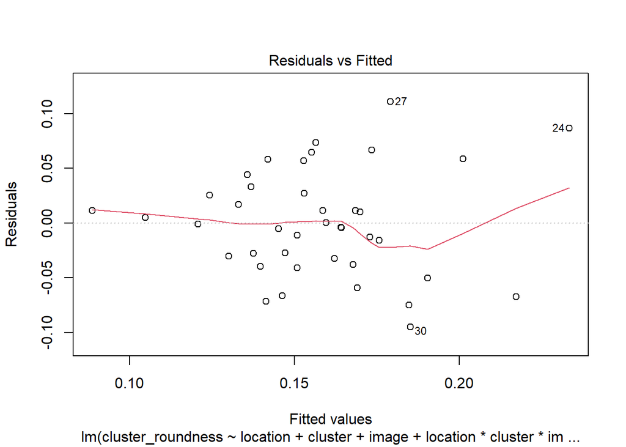

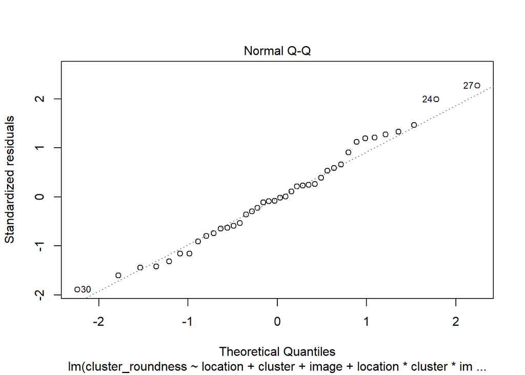

```r
plot(cl_rnd_b,which=c(1,2))
```

#compact shape factor ##Linear model and ANOVA

```r
cmp_shp <- lm(comp_shp_fact ~ location+cluster+image+date+location*cluster*image*date, data)
anova(cmp_shp)
```

```
## Analysis of Variance Table
##
## Response: comp_shp_fact
##                              Df Sum Sq Mean Sq F value    Pr(>F)
## location                      1  15286 15286.2 14.9355 0.0001939 ***
## cluster                       1  14335 14334.8 14.0060 0.0002989 ***
## image                         1    417   416.5  0.4069 0.5249249
## date                          1   1957  1957.0  1.9121 0.1696874
## location:cluster              1   9777  9777.2  9.5529 0.0025620 **
## location:image                1   1339  1338.9  1.3082 0.2553439
## cluster:image                 1      7     7.3  0.0071 0.9330742
## location:date                 1   8707  8707.2  8.5074 0.0043338 **
## cluster:date                  1     48    48.0  0.0469 0.8289245
## image:date                    1    169   169.3  0.1654 0.6850599
## location:cluster:image        1   4575  4575.0  4.4700 0.0368855 *
## location:cluster:date         1   1648  1648.0  1.6102 0.2072910
## location:image:date           1     40    39.9  0.0389 0.8439485
## cluster:image:date            1    381   380.6  0.3719 0.5433221
## location:cluster:image:date   1      2     1.9  0.0018 0.9660856
## Residuals                   104 106442  1023.5
## ---
## Signif. codes:  0 '***' 0.001 '**' 0.01 '*' 0.05 '.' 0.1 ' ' 1
```

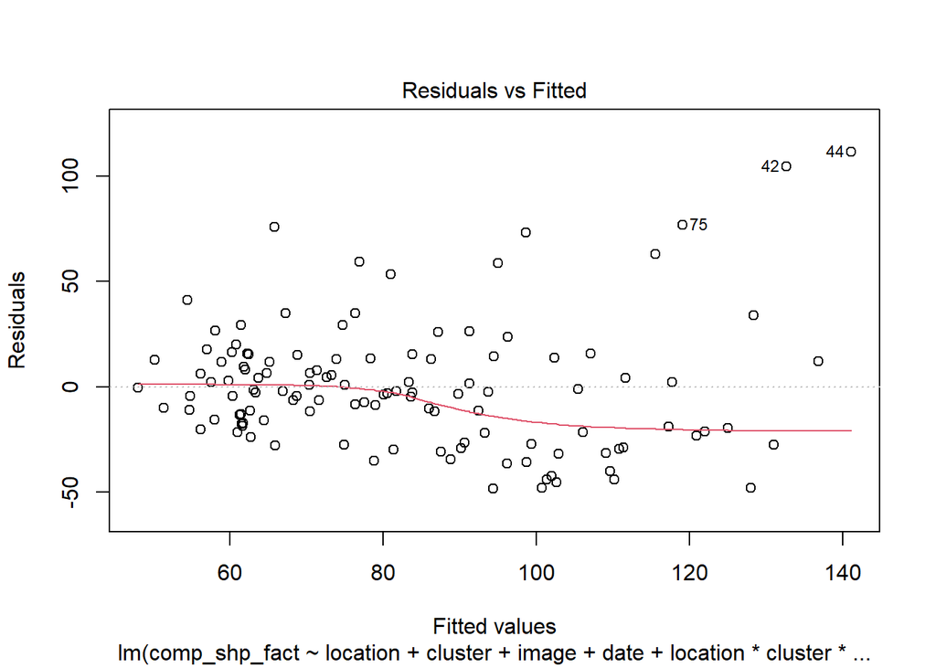

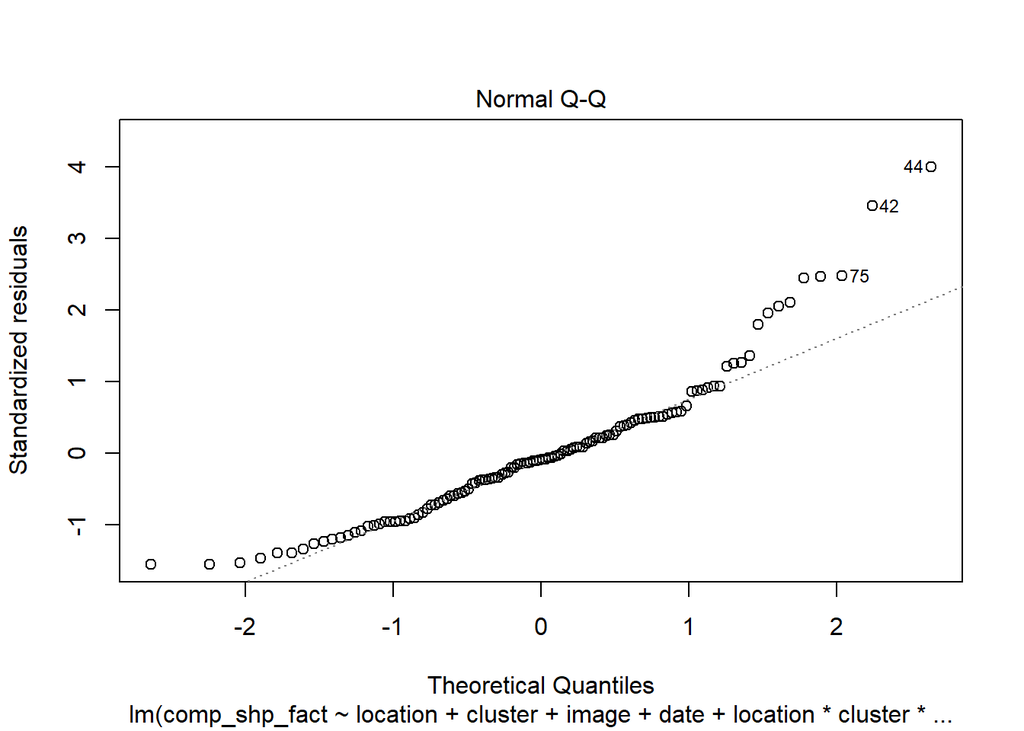

```r
plot(cmp_shp,which=c(1,2))
```

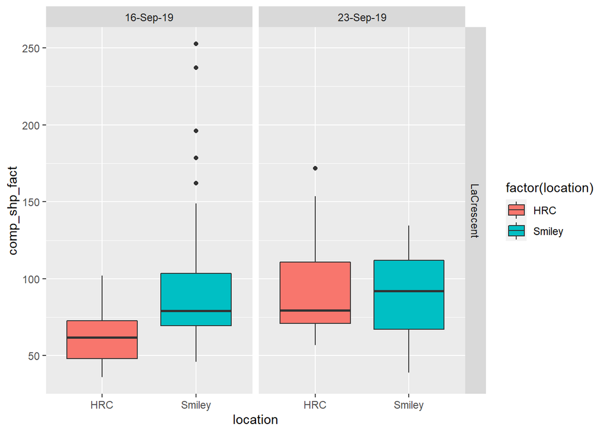

```r
ggplot(data, aes(comp_shp_fact, location, fill=factor(location)))+ #use this box plot!
  geom_boxplot()+
  coord_flip()+
  facet_grid(variety~date, scales="free")
```

##Linear model and ANOVA week a

```r
cmp_shp_a <- lm(comp_shp_fact ~ location+cluster+image+location*cluster*image, weeka)
anova(cmp_shp_a)
```

```
## Analysis of Variance Table
##
## Response: comp_shp_fact
##                        Df Sum Sq Mean Sq F value    Pr(>F)
## location                1  25159 25158.5 23.0258 8.404e-06 ***
## cluster                 1   8739  8738.7  7.9980 0.0060609 **
## image                   1      8     7.6  0.0069 0.9339632
## location:cluster        1  14164 14164.0 12.9633 0.0005802 ***
## location:image          1     98    98.1  0.0898 0.7653391
## cluster:image           1     28    27.7  0.0254 0.8738465
## location:cluster:image  1   1628  1628.0  1.4900 0.2261956
## Residuals              72  78669  1092.6
## ---
## Signif. codes:  0 '***' 0.001 '**' 0.01 '*' 0.05 '.' 0.1 ' ' 1
```

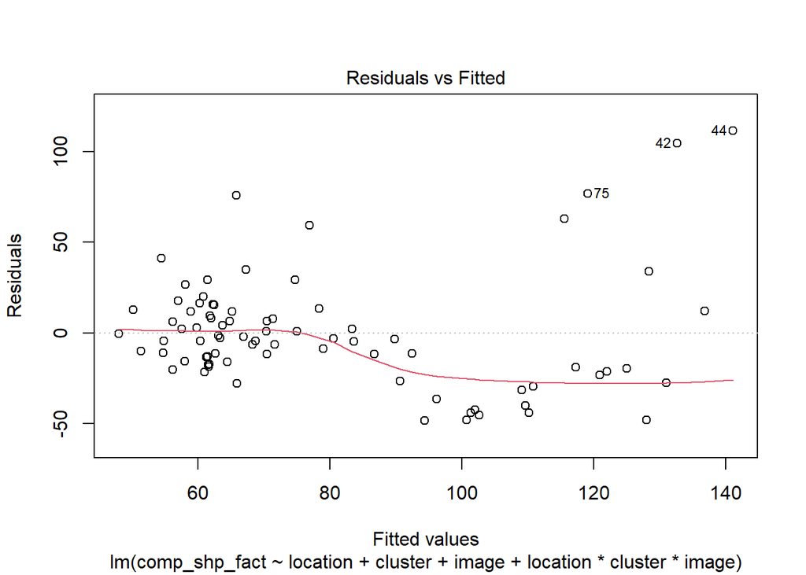

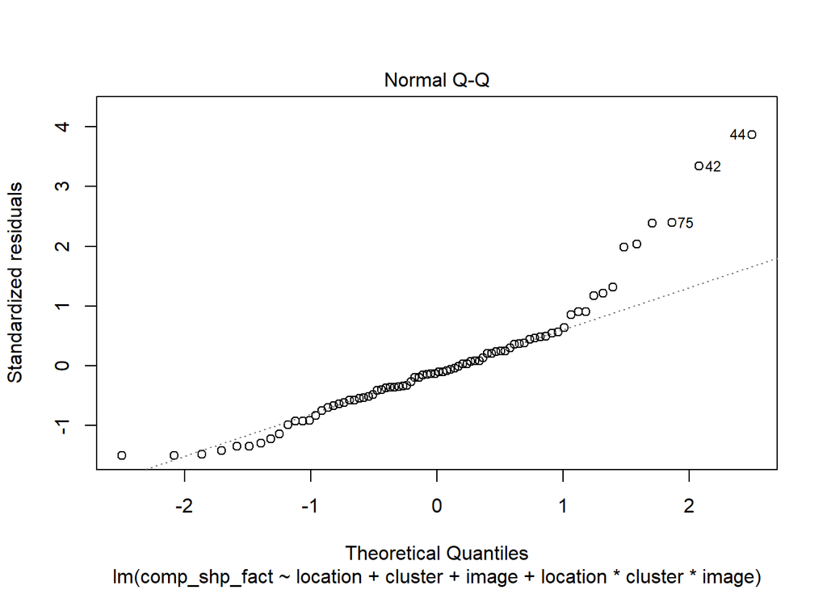

```r
plot(cmp_shp_a,which=c(1,2))
```

##Linear model and ANOVA week b

```r
cmp_shp_b <- lm(comp_shp_fact ~ location+cluster+image+location*cluster*image, weekb)
anova(cmp_shp_b)
```

```
## Analysis of Variance Table
##
## Response: comp_shp_fact
##                        Df  Sum Sq Mean Sq F value Pr(>F)
## location                1   103.4   103.4  0.1191 0.7322
## cluster                 1  5651.0  5651.0  6.5110 0.0157 *
## image                   1   163.3   163.3  0.1881 0.6674
## location:cluster        1     8.7     8.7  0.0101 0.9207
## location:image          1    12.2    12.2  0.0140 0.9065
## cluster:image           1   353.3   353.3  0.4070 0.5280
## location:cluster:image  1   201.3   201.3  0.2320 0.6333
## Residuals              32 27773.1   867.9
## ---
## Signif. codes:  0 '***' 0.001 '**' 0.01 '*' 0.05 '.' 0.1 ' ' 1
```

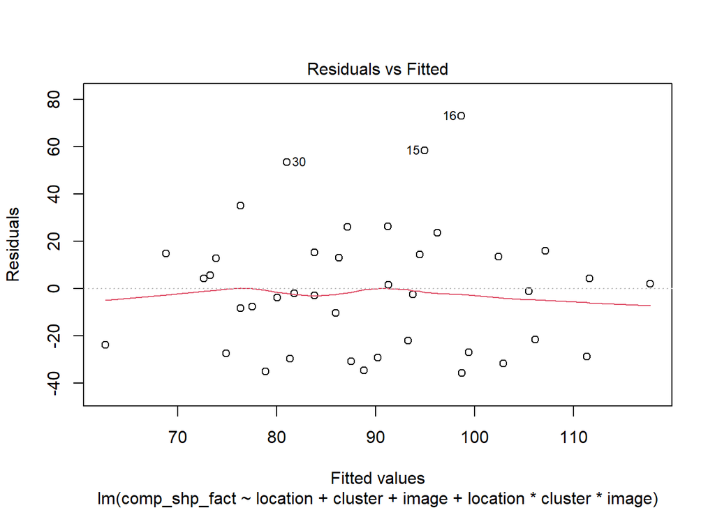

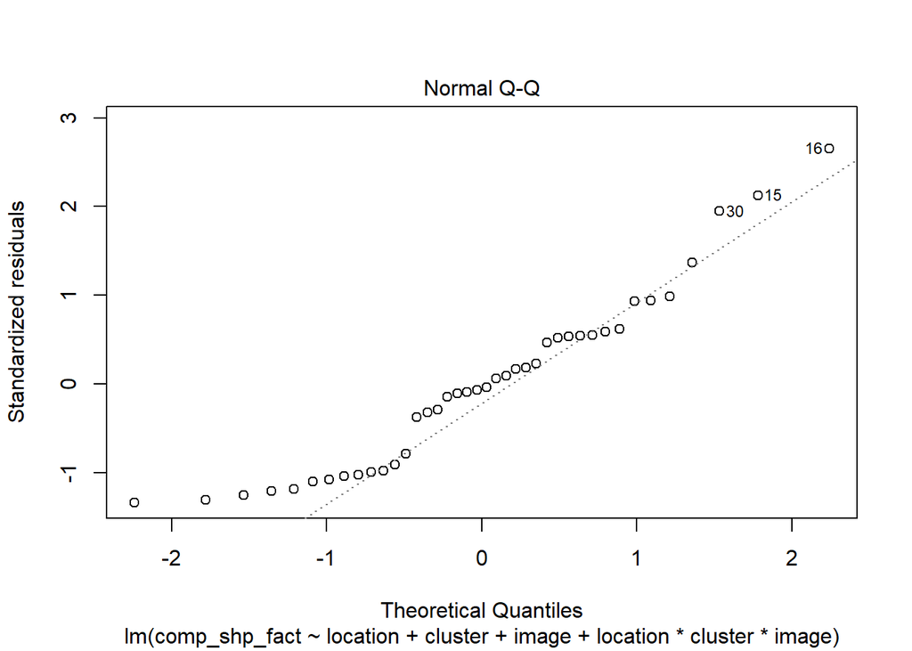

```r
plot(cmp_shp_b,which=c(1,2))
```

#Marquette ##load data

```r
data <- read.csv("Terroir_2019_Marquette.csv")
```

##partition data

```r
weeka <- filter(data, data$sample_week =="a")
weekb <- filter(data, data$sample_week =="b")
weekc <- filter(data, data$sample_week =="c")
```

#aspect ratio ##Linear model and ANOVA

```r
asp_rat <- lm(aspect_ratio ~ location+cluster+image+date+location*cluster*image*date, data)
anova(asp_rat)
```

```
## Analysis of Variance Table
##
## Response: aspect_ratio
##                              Df Sum Sq Mean Sq F value   Pr(>F)
## location                      5 2.2429 0.44859 11.7492 5.78e-10 ***
## cluster                       1 0.0586 0.05863  1.5356   0.2167
## image                         1 0.0077 0.00769  0.2014   0.6540
## date                          2 0.0027 0.00134  0.0352   0.9654
## location:cluster              5 0.2076 0.04153  1.0876   0.3684
## location:image                5 0.0830 0.01659  0.4345   0.8241
## cluster:image                 1 0.0001 0.00010  0.0025   0.9600
## location:date                 2 0.0561 0.02804  0.7345   0.4810
## cluster:date                  2 0.2467 0.12336  3.2309   0.0416 *
## image:date                    2 0.0088 0.00438  0.1148   0.8916
## location:cluster:image        5 0.0319 0.00638  0.1671   0.9744
## location:cluster:date         2 0.0294 0.01472  0.3856   0.6806
## location:image:date           2 0.0302 0.01512  0.3960   0.6735
## cluster:image:date            2 0.0367 0.01835  0.4806   0.6191
## location:cluster:image:date   2 0.0583 0.02915  0.7635   0.4674
## Residuals                   199 7.5979 0.03818
## ---
## Signif. codes:  0 '***' 0.001 '**' 0.01 '*' 0.05 '.' 0.1 ' ' 1
```

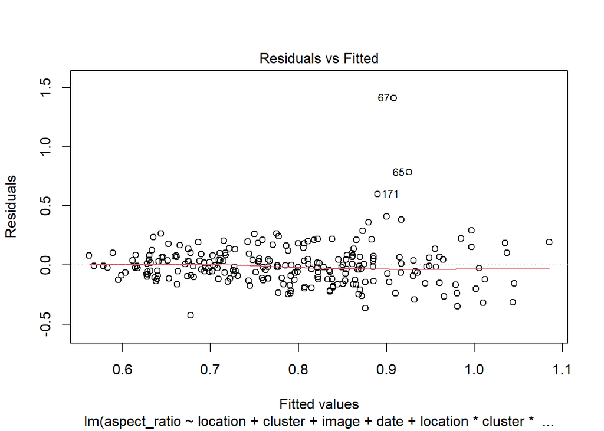

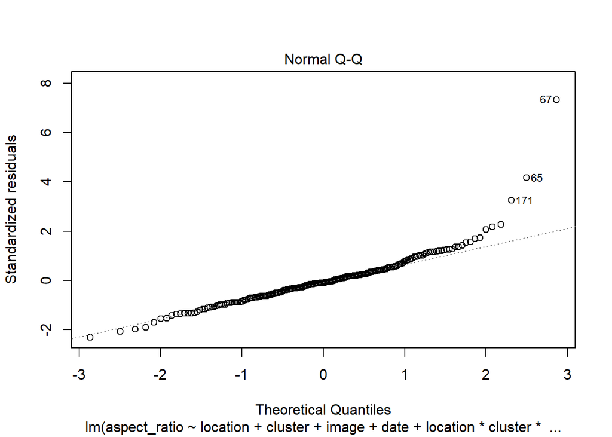

```r
plot(asp_rat,which=c(1,2))
```

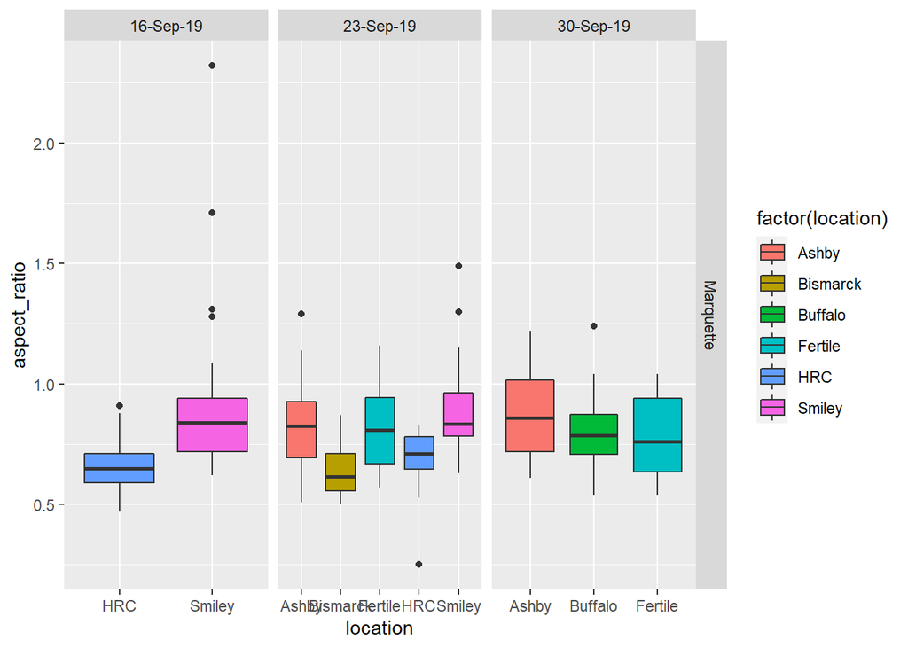

```r
ggplot(data, aes(aspect_ratio, location, fill=factor(location)))+ #use this box plot!
  geom_boxplot()+
  coord_flip()+
  facet_grid(variety~date, scales="free")
```

##Linear model and ANOVA Week a only

```r
asp_rat_a <- lm(aspect_ratio ~ location+cluster+image+location*cluster*image, weeka)
anova(asp_rat_a)
```

```
## Analysis of Variance Table
##
## Response: aspect_ratio
##                        Df Sum Sq Mean Sq F value    Pr(>F)
## location                1 1.1376 1.13764 21.5082 1.536e-05 ***
## cluster                 1 0.2696 0.26963  5.0976   0.02699 *
## image                   1 0.0035 0.00348  0.0658   0.79827
## location:cluster        1 0.0355 0.03549  0.6710   0.41539
## location:image          1 0.0106 0.01061  0.2006   0.65560
## cluster:image           1 0.0237 0.02368  0.4477   0.50557
## location:cluster:image  1 0.0069 0.00692  0.1309   0.71856
## Residuals              72 3.8083 0.05289
## ---
## Signif. codes:  0 '***' 0.001 '**' 0.01 '*' 0.05 '.' 0.1 ' ' 1
```

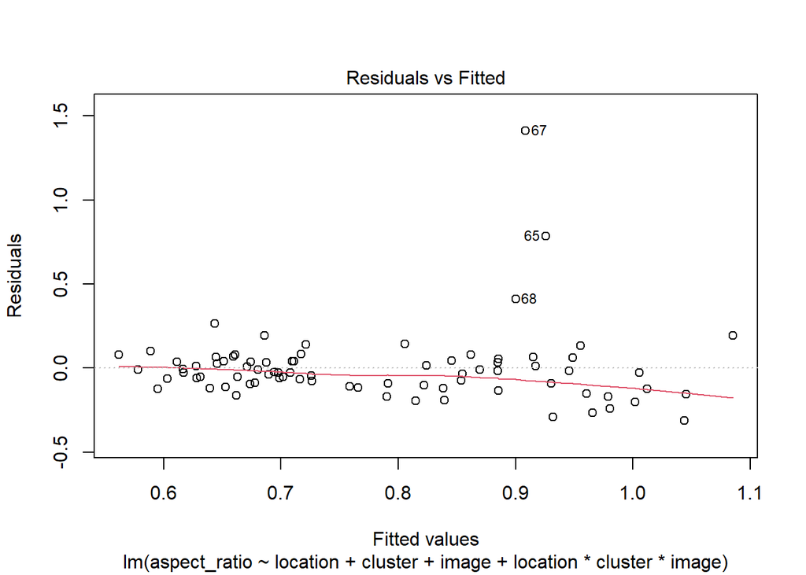

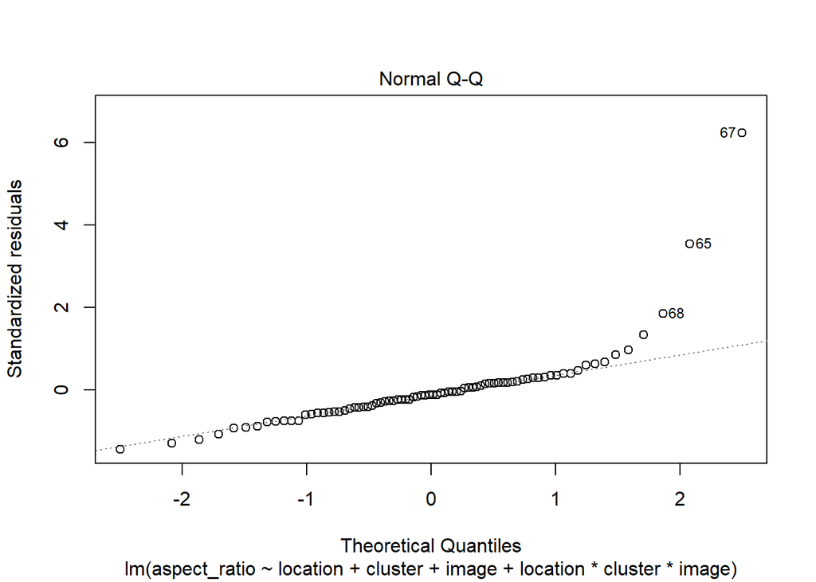

```r
plot(asp_rat_a,which=c(1,2))
```

##Linear model and ANOVA Week b only

```r
asp_rat_b <- lm(aspect_ratio ~ location+cluster+image+cluster*image*location, weekb)
anova(asp_rat_b)
```

```
## Analysis of Variance Table
##
## Response: aspect_ratio
##                        Df  Sum Sq  Mean Sq F value    Pr(>F)
## location                4 0.96077 0.240193  8.2330 1.329e-05 ***
## cluster                 1 0.06744 0.067439  2.3116    0.1324
## image                   1 0.03087 0.030868  1.0580    0.3068
## cluster:image           1 0.00096 0.000955  0.0327    0.8569
## location:cluster        4 0.08582 0.021454  0.7354    0.5706
## location:image          4 0.04861 0.012151  0.4165    0.7963
## location:cluster:image  4 0.07544 0.018860  0.6465    0.6310
## Residuals              79 2.30477 0.029174
## ---
## Signif. codes:  0 '***' 0.001 '**' 0.01 '*' 0.05 '.' 0.1 ' ' 1
```

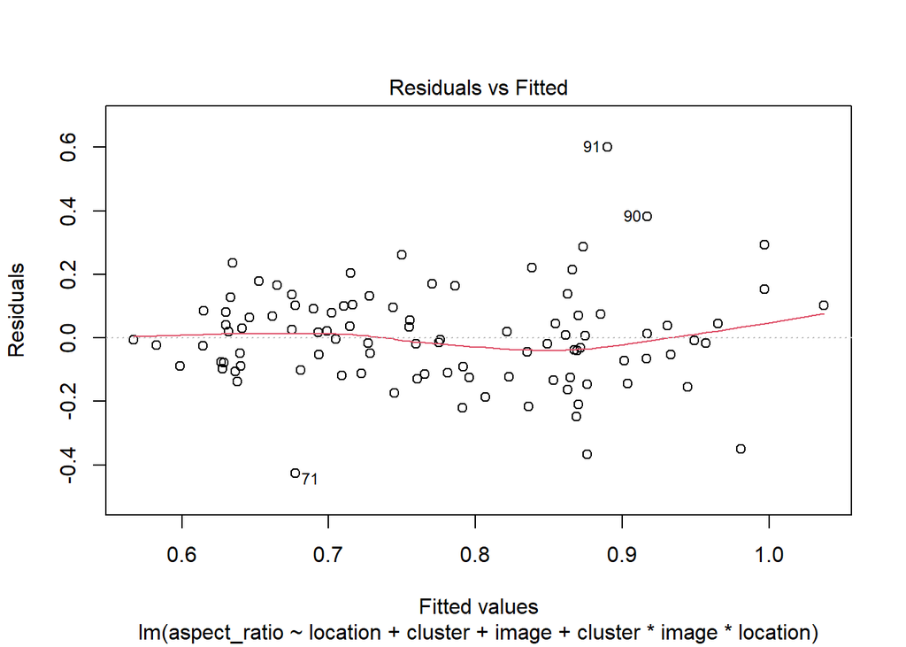

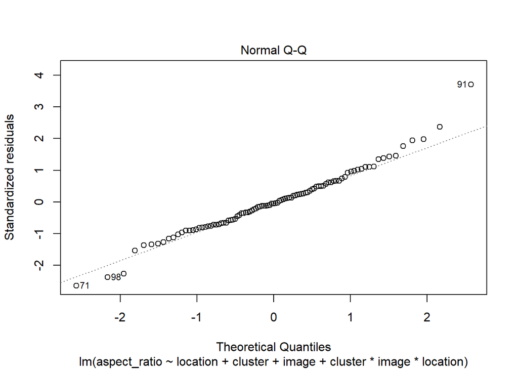

```r
plot(asp_rat_b,which=c(1,2))
```

##Linear model and ANOVA Week c only

```r
asp_rat_c <- lm(aspect_ratio ~ location+cluster+image+cluster*image*location, weekc)
anova(asp_rat_c)
```

```
## Analysis of Variance Table
##
## Response: aspect_ratio
##                        Df  Sum Sq  Mean Sq F value Pr(>F)
## location                2 0.11109 0.055545  1.7957 0.1770
## cluster                 1 0.04831 0.048307  1.5617 0.2175
## image                   1 0.01350 0.013500  0.4364 0.5120
## cluster:image           1 0.02517 0.025174  0.8138 0.3715
## location:cluster        2 0.00292 0.001459  0.0472 0.9540
## location:image          2 0.02683 0.013415  0.4337 0.6506
## location:cluster:image  2 0.02875 0.014375  0.4647 0.6311
## Residuals              48 1.48477 0.030933
```

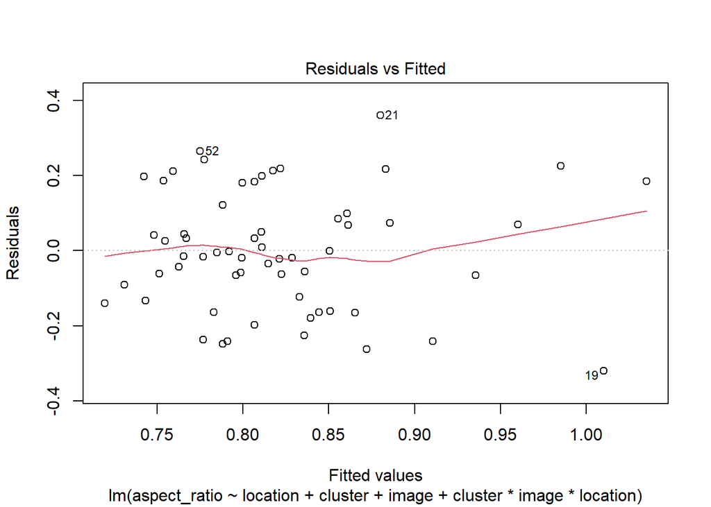

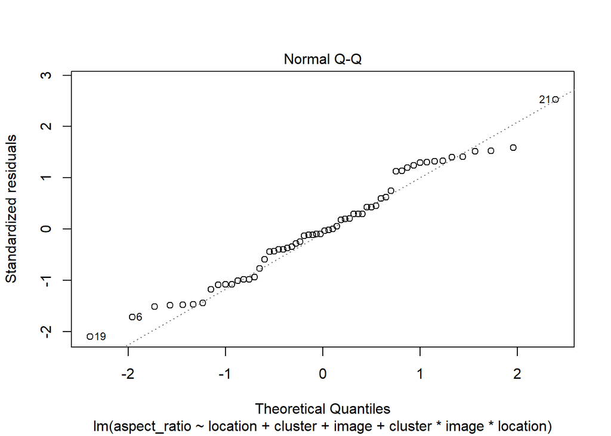

```r
plot(asp_rat_c,which=c(1,2))
```

#cluster roundness ##Linear model and ANOVA

```r
cl_rnd <- lm(cluster_roundness ~ location+cluster+image+date+location*cluster*image*date, data)
anova(cl_rnd)
```

```
## Analysis of Variance Table
##
## Response: cluster_roundness
##                              Df  Sum Sq  Mean Sq F value    Pr(>F)
## location                      5 0.76124 0.152247 29.4886 < 2.2e-16 ***
## cluster                       1 0.07373 0.073730 14.2807  0.000208 ***
## image                         1 0.01135 0.011349  2.1982  0.139755
## date                          2 0.12563 0.062814 12.1663 1.035e-05 ***
## location:cluster              5 0.02306 0.004612  0.8932  0.486607
## location:image                5 0.00657 0.001313  0.2544  0.937253
## cluster:image                 1 0.00700 0.007004  1.3566  0.245528
## location:date                 2 0.01391 0.006953  1.3466  0.262472
## cluster:date                  2 0.01504 0.007519  1.4563  0.235576
## image:date                    2 0.00178 0.000889  0.1722  0.841956
## location:cluster:image        5 0.01331 0.002662  0.5156  0.764321
## location:cluster:date         2 0.03460 0.017300  3.3508  0.037044 *
## location:image:date           2 0.00111 0.000557  0.1079  0.897788
## cluster:image:date            2 0.00045 0.000226  0.0439  0.957099
## location:cluster:image:date   2 0.00377 0.001885  0.3651  0.694595
## Residuals                   199 1.02742 0.005163
## ---
## Signif. codes:  0 '***' 0.001 '**' 0.01 '*' 0.05 '.' 0.1 ' ' 1
```

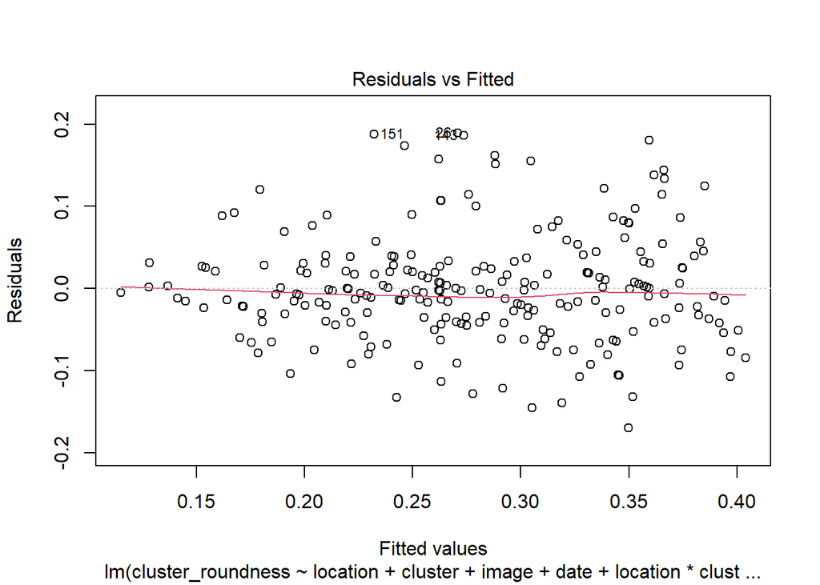

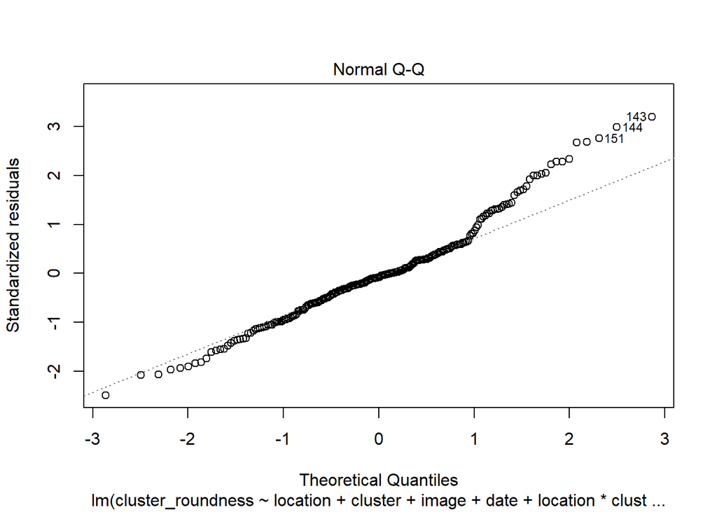

```r
plot(cl_rnd,which=c(1,2))
```

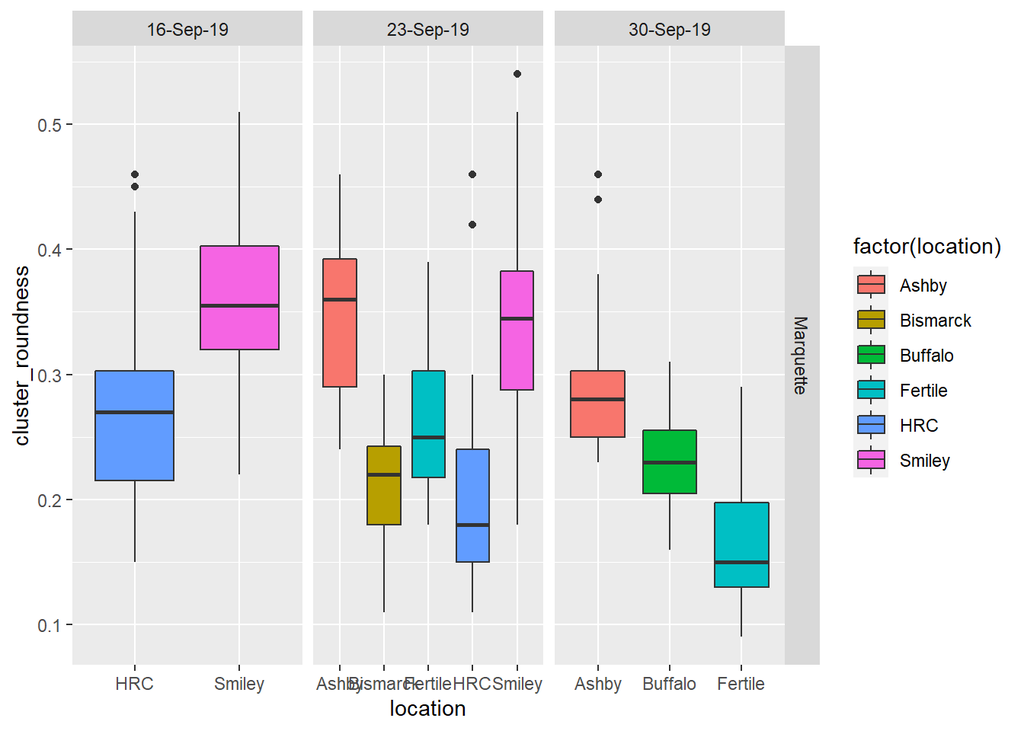

```r
ggplot(data, aes(cluster_roundness, location, fill=factor(location)))+ #use this box plot!
  geom_boxplot()+
  coord_flip()+
  facet_grid(variety~date, scales="free")
```

##Linear model and ANOVA week a

```r
cl_rnd_a <- lm(cluster_roundness ~ location+cluster+image+location*cluster*image, weeka)
anova(cl_rnd_a)
```

```
## Analysis of Variance Table
##
## Response: cluster_roundness
##                        Df  Sum Sq  Mean Sq F value    Pr(>F)
## location                1 0.17112 0.171125 34.0801 1.406e-07 ***
## cluster                 1 0.06560 0.065601 13.0646 0.0005542 ***
## image                   1 0.00168 0.001681  0.3348 0.5646652
## location:cluster        1 0.00193 0.001935  0.3853 0.5367395
## location:image          1 0.00102 0.001024  0.2039 0.6529220
## cluster:image           1 0.00054 0.000536  0.1068 0.7448202
## location:cluster:image  1 0.00255 0.002548  0.5075 0.4785082
## Residuals              72 0.36153 0.005021
## ---
## Signif. codes:  0 '***' 0.001 '**' 0.01 '*' 0.05 '.' 0.1 ' ' 1
```

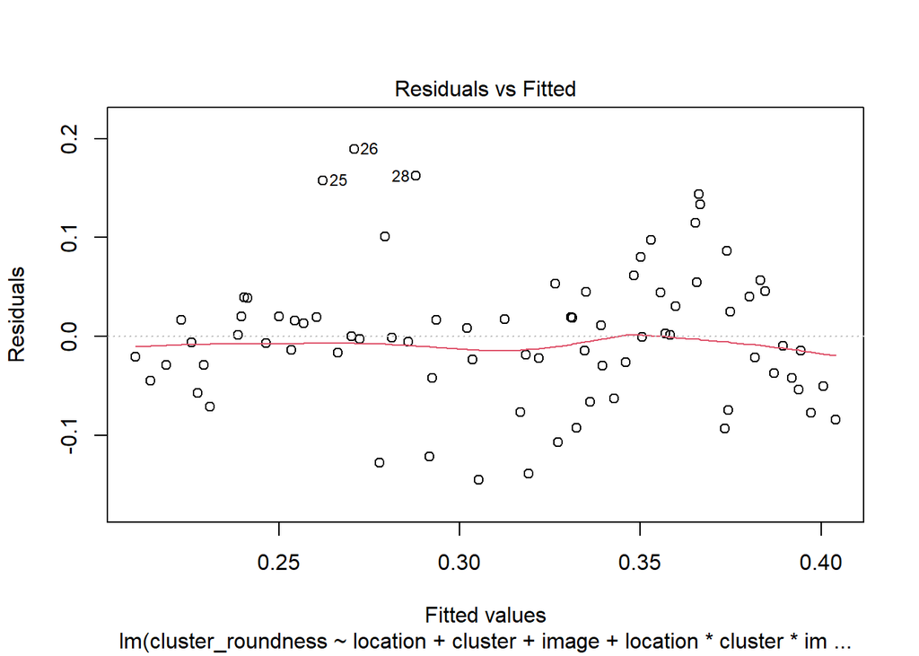

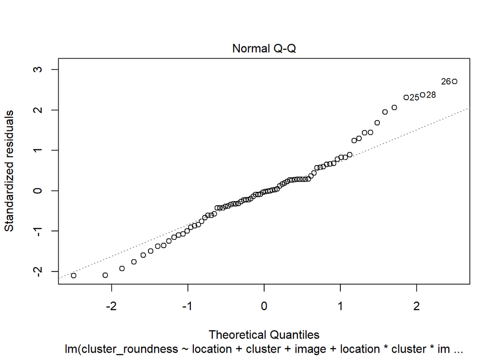

```r
plot(cl_rnd_a,which=c(1,2))
```

##Linear model and ANOVA week b

```r
cl_rnd_b <- lm(cluster_roundness ~ location+cluster+image +location*cluster*image, weekb)
anova(cl_rnd_b)
```

```
## Analysis of Variance Table
##
## Response: cluster_roundness
##                        Df  Sum Sq  Mean Sq F value    Pr(>F)
## location                4 0.34565 0.086413 13.0140 3.461e-08 ***
## cluster                 1 0.00757 0.007568  1.1397    0.2890
## image                   1 0.00000 0.000002  0.0002    0.9877
## location:cluster        4 0.05064 0.012659  1.9065    0.1175
## location:image          4 0.00305 0.000763  0.1149    0.9769
## cluster:image           1 0.00055 0.000553  0.0833    0.7737
## location:cluster:image  4 0.00244 0.000611  0.0920    0.9847
## Residuals              79 0.52456 0.006640
## ---
## Signif. codes:  0 '***' 0.001 '**' 0.01 '*' 0.05 '.' 0.1 ' ' 1
```

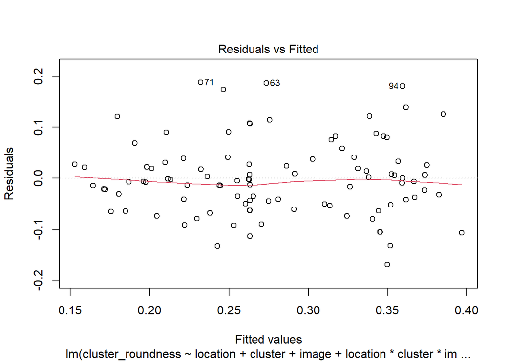

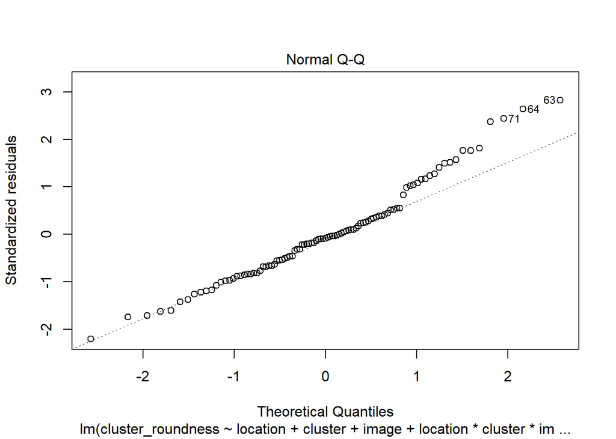

```r
plot(cl_rnd_b,which=c(1,2))
```

```r
cl_rnd_c <- lm(cluster_roundness ~ location+cluster+image +location*cluster*image, weekc)
anova(cl_rnd_c)
```

```
## Analysis of Variance Table
##
## Response: cluster_roundness
##                        Df   Sum Sq  Mean Sq F value    Pr(>F)
## location                2 0.156333 0.078167 26.5483 1.722e-08 ***
## cluster                 1 0.017107 0.017107  5.8103   0.01981 *
## image                   1 0.000807 0.000807  0.2740   0.60309
## location:cluster        2 0.019696 0.009848  3.3447   0.04366 *
## location:image          2 0.001853 0.000927  0.3147   0.73148
## cluster:image           1 0.000010 0.000010  0.0034   0.95400
## location:cluster:image  2 0.001300 0.000650  0.2207   0.80274
## Residuals              48 0.141327 0.002944
## ---
## Signif. codes:  0 '***' 0.001 '**' 0.01 '*' 0.05 '.' 0.1 ' ' 1
```

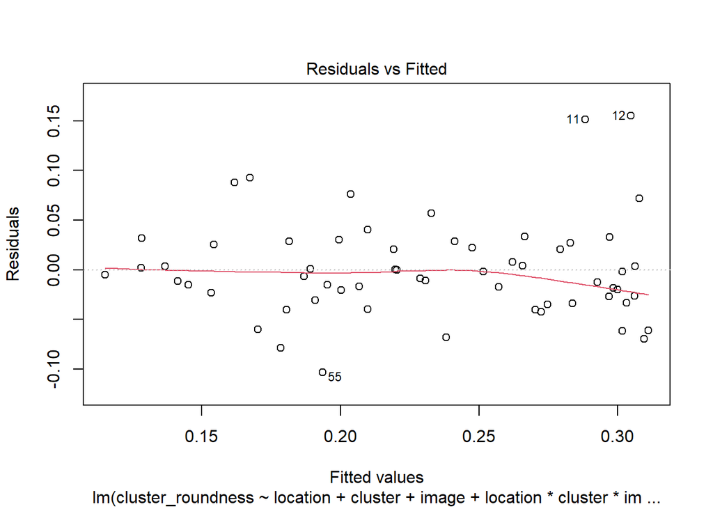

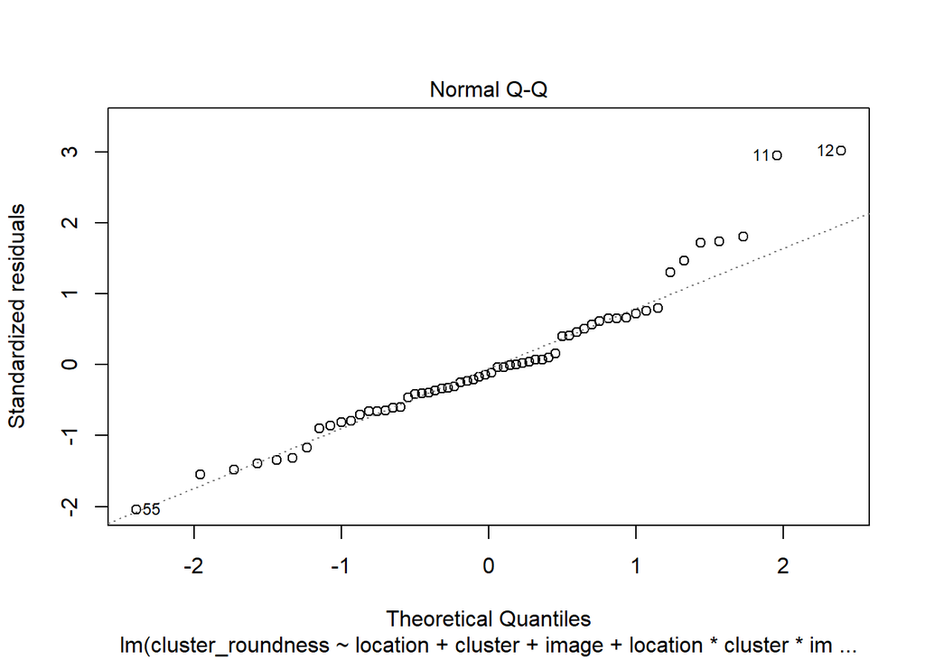

```r
plot(cl_rnd_c,which=c(1,2))
```

#compact shape factor ##Linear model and ANOVA

```r
cmp_shp <- lm(comp_shp_fact ~ location+cluster+image+date+location*cluster*image*date, data)
anova(cmp_shp)
```

```
## Analysis of Variance Table
##
## Response: comp_shp_fact
##                              Df Sum Sq Mean Sq F value    Pr(>F)
## location                      5  30762  6152.3 27.1318 < 2.2e-16 ***
## cluster                       1   3695  3694.8 16.2939 7.735e-05 ***
## image                         1    759   759.4  3.3490   0.06874 .
## date                          2   9858  4928.8 21.7362 2.897e-09 ***
## location:cluster              5   2166   433.1  1.9101   0.09420 .
## location:image                5    660   132.0  0.5823   0.71353
## cluster:image                 1     96    96.1  0.4238   0.51582
## location:date                 2   4630  2315.0 10.2090 6.016e-05 ***
## cluster:date                  2    722   360.9  1.5914   0.20621
## image:date                    2     13     6.7  0.0294   0.97104
## location:cluster:image        5    178    35.5  0.1566   0.97784
## location:cluster:date         2   1405   702.3  3.0973   0.04735 *
## location:image:date           2     31    15.6  0.0689   0.93345
## cluster:image:date            2     44    22.2  0.0977   0.90695
## location:cluster:image:date   2    234   117.1  0.5163   0.59753
## Residuals                   199  45125   226.8
## ---
## Signif. codes:  0 '***' 0.001 '**' 0.01 '*' 0.05 '.' 0.1 ' ' 1
```

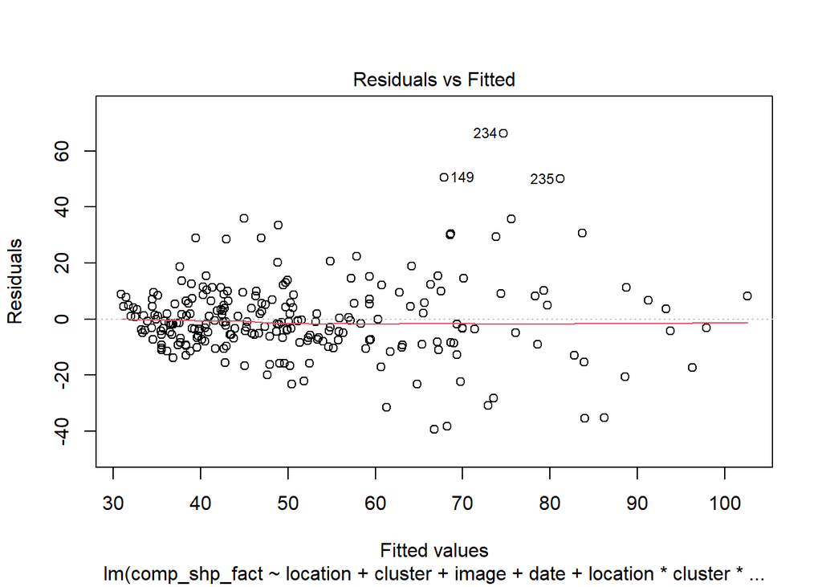

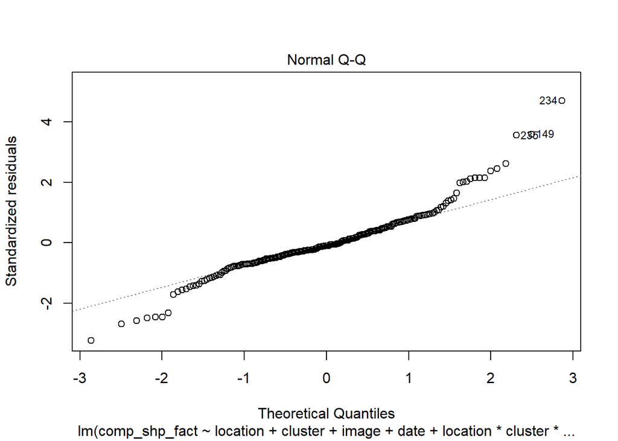

```r
plot(cmp_shp,which=c(1,2))
```

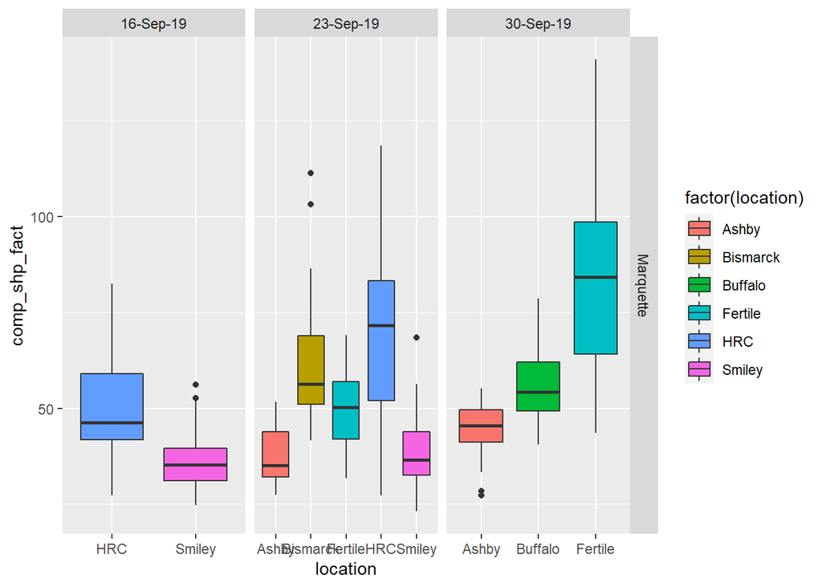

```r
ggplot(data, aes(comp_shp_fact, location, fill=factor(location)))+ #use this box plot!
  geom_boxplot()+
  coord_flip()+
  facet_grid(variety~date, scales="free")
```

##Linear model and ANOVA week a

```r
cmp_shp_a <- lm(comp_shp_fact ~ location+cluster+image+location*cluster*image, weeka)
anova(cmp_shp_a)
```

```
## Analysis of Variance Table
##
## Response: comp_shp_fact
##                        Df Sum Sq Mean Sq F value    Pr(>F)
## location                1 4290.8  4290.8 33.0573 2.011e-07 ***
## cluster                 1 1449.6  1449.6 11.1676  0.001322 **
## image                   1   42.3    42.3  0.3260  0.569830
## location:cluster        1  122.2   122.2  0.9418  0.335066
## location:image          1   38.3    38.3  0.2951  0.588620
## cluster:image           1    8.9     8.9  0.0686  0.794161
## location:cluster:image  1   25.4    25.4  0.1955  0.659719
## Residuals              72 9345.6   129.8
## ---
## Signif. codes:  0 '***' 0.001 '**' 0.01 '*' 0.05 '.' 0.1 ' ' 1
```

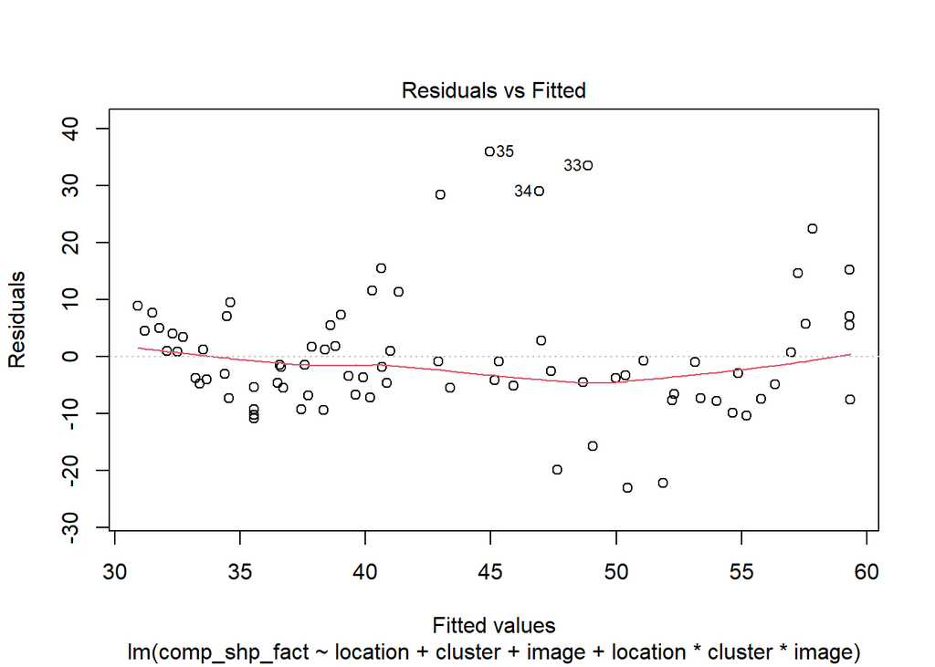

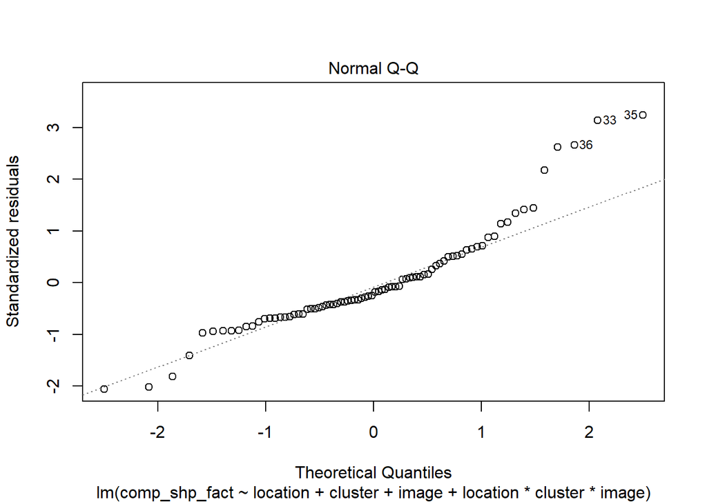

```r
plot(cmp_shp_a,which=c(1,2))
```

##Linear model and ANOVA week b

```r
cmp_shp_b <- lm(comp_shp_fact ~ location+cluster+image+location*cluster*image, weekb)
anova(cmp_shp_b)
```

```
## Analysis of Variance Table
##
## Response: comp_shp_fact
##                        Df  Sum Sq Mean Sq F value    Pr(>F)
## location                4 15149.1  3787.3 14.4365 6.841e-09 ***
## cluster                 1   725.8   725.8  2.7667   0.10021
## image                   1     5.0     5.0  0.0191   0.89034
## location:cluster        4  2776.7   694.2  2.6461   0.03949 *
## location:image          4    58.8    14.7  0.0561   0.99404
## cluster:image           1     0.1     0.1  0.0004   0.98329
## location:cluster:image  4    85.7    21.4  0.0817   0.98779
## Residuals              79 20724.9   262.3
## ---
## Signif. codes:  0 '***' 0.001 '**' 0.01 '*' 0.05 '.' 0.1 ' ' 1
```

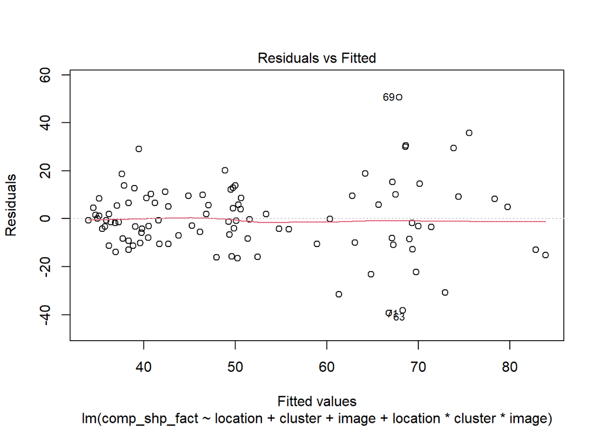

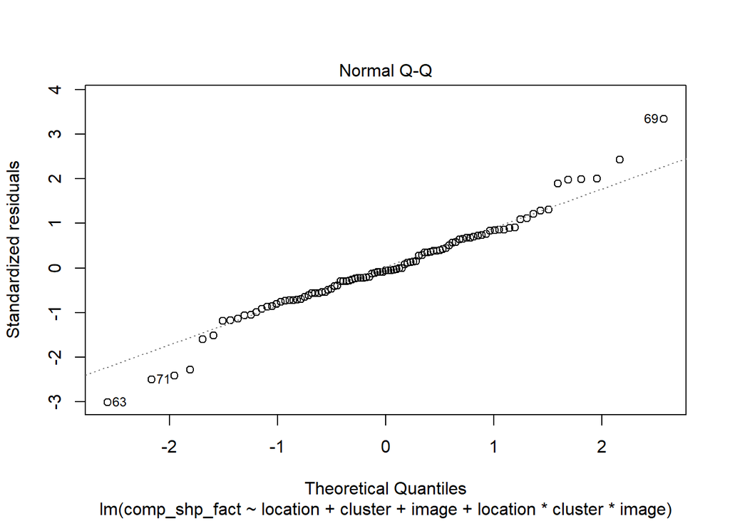

```r
plot(cmp_shp_b,which=c(1,2))
```

##Linear model and ANOVA week c

```r
cmp_shp_c <- lm(comp_shp_fact ~ location+cluster+image+location*cluster*image, weekc)
anova(cmp_shp_c)
```

```
## Analysis of Variance Table
##
## Response: comp_shp_fact
##                        Df  Sum Sq Mean Sq F value    Pr(>F)
## location                2 16039.9  8020.0 25.5715 2.751e-08 ***
## cluster                 1  1718.6  1718.6  5.4797   0.02344 *
## image                   1    14.6    14.6  0.0467   0.82985
## location:cluster        2  1339.0   669.5  2.1346   0.12938
## location:image          2   139.4    69.7  0.2222   0.80156
## cluster:image           1    18.4    18.4  0.0585   0.80989
## location:cluster:image  2   201.0   100.5  0.3205   0.72733
## Residuals              48 15054.2   313.6
## ---
## Signif. codes:  0 '***' 0.001 '**' 0.01 '*' 0.05 '.' 0.1 ' ' 1
```

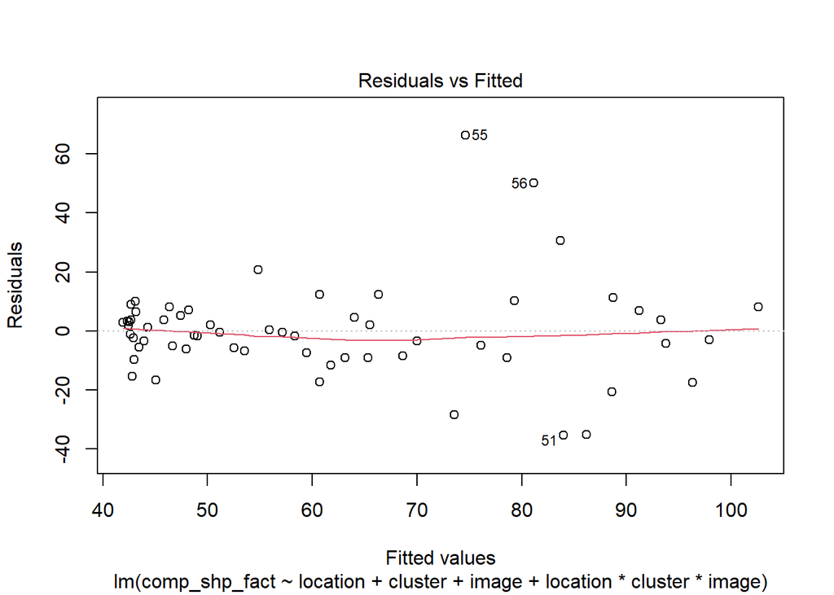

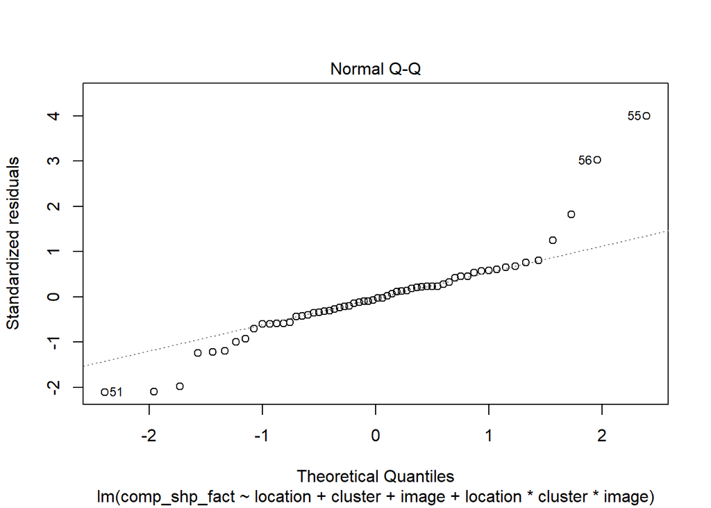

```r
plot(cmp_shp_c,which=c(1,2))
```